# 2. Six-Sided Die

- Show All Code
- Hide All Code
- View Source

Discrete, flat, and perfectly symmetric

Author

Richa Vakharia

```r
source("R/clt_helpers.R")
roll_die <- function(k) sample(1:6, size = k, replace = TRUE)
```

## 1 What population am I sampling from?

A fair die: values 1 through 6, each with probability 1/6, simulated with `sample(1:6, replace = TRUE)`. It’s **discrete** (only 6 possible values), **bounded**, and **perfectly symmetric**, but it’s flat instead of bell-shaped, so its tails are *lighter* than a normal’s.

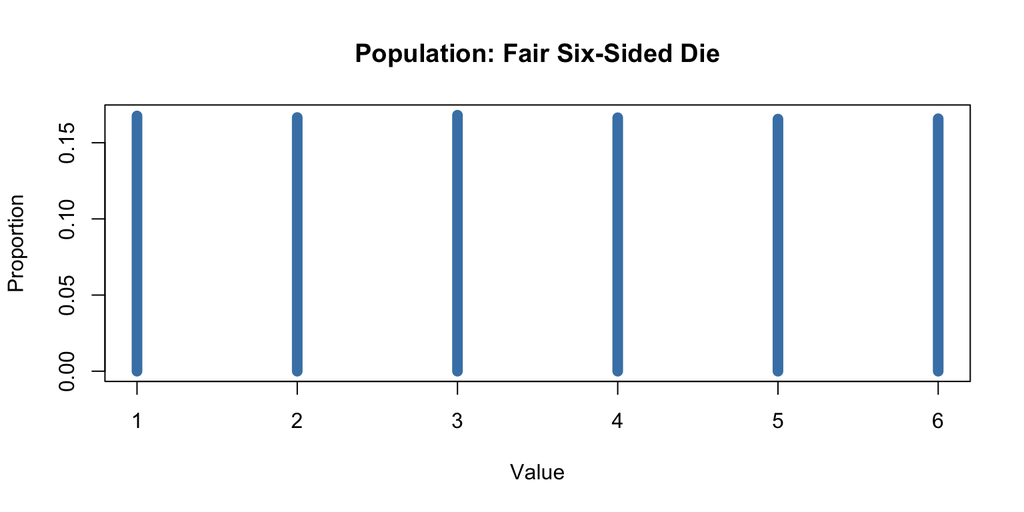

```r
plot_population(roll_die, "Population: Fair Six-Sided Die", discrete = TRUE)
```

```r
values <- 1:6
p      <- rep(1/6, 6)
mu     <- sum(values * p)                         # 3.5
sigma  <- sqrt(sum((values - mu)^2 * p))          # sqrt(35/12)
g1     <- sum(((values - mu) / sigma)^3 * p)      # skewness
g2     <- sum(((values - mu) / sigma)^4 * p) - 3  # excess kurtosis
data.frame(mean = mu, sd = sigma, skewness = g1, excess_kurtosis = g2)
```

```
  mean       sd skewness excess_kurtosis
1  3.5 1.707825        0       -1.268571
```

## 2 What did I expect?

Since the die is symmetric, skewness is 0 at every $n$, so skewness won’t be the problem. The issue is the flat shape: excess kurtosis starts at -1.269 (light tails) and shrinks like $g_2/n$. I also expect discreteness to matter at small $n$ because the mean of $n$ rolls can only take $5n + 1$ different values.

```r
predicted_n(g1, g2)
```

```
  from_skewness from_kurtosis prediction
1             0             3          3
```

The theory predicts my kurtosis cutoff is crossed around $n = 3$. I think the Q-Q plot will look “stair-steppy” for a while longer than that because of the discreteness, so my actual guess is somewhere between 3 and 10.

## 3 Which sample sizes did I investigate?

The standard grid from 1 to 500 (same for every population), with $B = 10,000$ repetitions at each $n$.

## 4 Simulation

```r
sweep  <- run_sweep(function(n) simulate_means(roll_die, n, B), mu = mu, sigma = sigma)
tab    <- sweep$table
n_star <- chosen_n(tab)
show_table(tab)
```

| n | sim_mean | theo_mean | sim_se | theo_se | se_ratio | skewness | ex_kurt | qq_cor | qq_dist | shapiro_p | normal_enough |
| --- | --- | --- | --- | --- | --- | --- | --- | --- | --- | --- | --- |
| 1 | 3.471 | 3.5 | 1.70900 | 1.70800 | 1.0010 | 0.0203700 | -1.264000 | 0.9520 | 0.28200 | < 1e-04 | FALSE |
| 2 | 3.484 | 3.5 | 1.21000 | 1.20800 | 1.0020 | 0.0184800 | -0.637600 | 0.9875 | 0.19560 | < 1e-04 | FALSE |
| 3 | 3.507 | 3.5 | 0.98380 | 0.98600 | 0.9978 | 0.0013610 | -0.429600 | 0.9935 | 0.21080 | < 1e-04 | FALSE |
| 4 | 3.506 | 3.5 | 0.85460 | 0.85390 | 1.0010 | 0.0009615 | -0.319000 | 0.9956 | 0.13110 | < 1e-04 | FALSE |
| 5 | 3.486 | 3.5 | 0.75520 | 0.76380 | 0.9888 | -0.0371500 | -0.231700 | 0.9966 | 0.07142 | < 1e-04 | FALSE |
| 6 | 3.506 | 3.5 | 0.68620 | 0.69720 | 0.9841 | 0.0047780 | -0.242900 | 0.9971 | 0.08620 | < 1e-04 | FALSE |
| 8 | 3.494 | 3.5 | 0.60100 | 0.60380 | 0.9954 | -0.0309200 | -0.202200 | 0.9979 | 0.08039 | < 1e-04 | FALSE |
| 10 | 3.502 | 3.5 | 0.54630 | 0.54010 | 1.0120 | 0.0106500 | -0.084620 | 0.9985 | 0.08007 | < 1e-04 | TRUE |
| 12 | 3.502 | 3.5 | 0.49370 | 0.49300 | 1.0010 | -0.0295200 | -0.112400 | 0.9986 | 0.04433 | < 1e-04 | TRUE |
| 15 | 3.499 | 3.5 | 0.44550 | 0.44100 | 1.0100 | 0.0102100 | -0.171700 | 0.9988 | 0.03983 | < 1e-04 | TRUE |
| 20 | 3.495 | 3.5 | 0.38440 | 0.38190 | 1.0070 | 0.0224100 | -0.073600 | 0.9992 | 0.04423 | < 1e-04 | TRUE |
| 25 | 3.501 | 3.5 | 0.33880 | 0.34160 | 0.9918 | -0.0300800 | -0.028040 | 0.9993 | 0.04133 | 0.00014 | TRUE |
| 30 | 3.501 | 3.5 | 0.31170 | 0.31180 | 0.9996 | 0.0331700 | -0.044420 | 0.9994 | 0.04665 | < 1e-04 | TRUE |
| 35 | 3.496 | 3.5 | 0.28960 | 0.28870 | 1.0030 | -0.0156200 | -0.136100 | 0.9994 | 0.04936 | 0.00013 | TRUE |
| 40 | 3.503 | 3.5 | 0.27160 | 0.27000 | 1.0060 | -0.0477100 | -0.067060 | 0.9995 | 0.04502 | 0.00067 | TRUE |
| 45 | 3.500 | 3.5 | 0.25460 | 0.25460 | 1.0000 | 0.0050830 | -0.033460 | 0.9996 | 0.03202 | 0.00418 | TRUE |
| 50 | 3.498 | 3.5 | 0.24240 | 0.24150 | 1.0030 | 0.0079860 | -0.060100 | 0.9996 | 0.02826 | 0.00043 | TRUE |
| 60 | 3.501 | 3.5 | 0.21920 | 0.22050 | 0.9940 | -0.0148600 | 0.001778 | 0.9997 | 0.02320 | 0.01958 | TRUE |
| 70 | 3.500 | 3.5 | 0.20610 | 0.20410 | 1.0100 | 0.0225700 | -0.014980 | 0.9996 | 0.02871 | 0.00206 | TRUE |
| 80 | 3.499 | 3.5 | 0.19100 | 0.19090 | 1.0000 | -0.0180000 | -0.039800 | 0.9997 | 0.02955 | 0.06031 | TRUE |
| 90 | 3.498 | 3.5 | 0.18070 | 0.18000 | 1.0040 | 0.0011920 | 0.024660 | 0.9998 | 0.01834 | 0.04196 | TRUE |
| 100 | 3.503 | 3.5 | 0.17150 | 0.17080 | 1.0040 | -0.0221000 | 0.001077 | 0.9998 | 0.01913 | 0.18248 | TRUE |
| 125 | 3.501 | 3.5 | 0.15240 | 0.15280 | 0.9979 | -0.0210800 | -0.068170 | 0.9998 | 0.02374 | 0.07801 | TRUE |
| 150 | 3.502 | 3.5 | 0.14020 | 0.13940 | 1.0050 | -0.0623000 | -0.058970 | 0.9997 | 0.02346 | 0.01211 | TRUE |
| 200 | 3.500 | 3.5 | 0.12130 | 0.12080 | 1.0040 | -0.0344500 | -0.029780 | 0.9998 | 0.02010 | 0.23223 | TRUE |
| 300 | 3.499 | 3.5 | 0.09895 | 0.09860 | 1.0040 | 0.0632600 | 0.037240 | 0.9998 | 0.01797 | 0.23249 | TRUE |
| 500 | 3.500 | 3.5 | 0.07572 | 0.07638 | 0.9915 | 0.0035560 | 0.088850 | 0.9998 | 0.01919 | 0.59316 | TRUE |

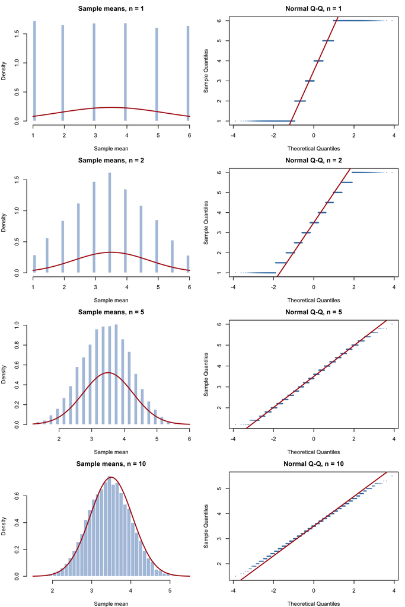

```r
plot_sampling(sweep, c(1, 2, 5, n_star), mu = mu, sigma = sigma)
```

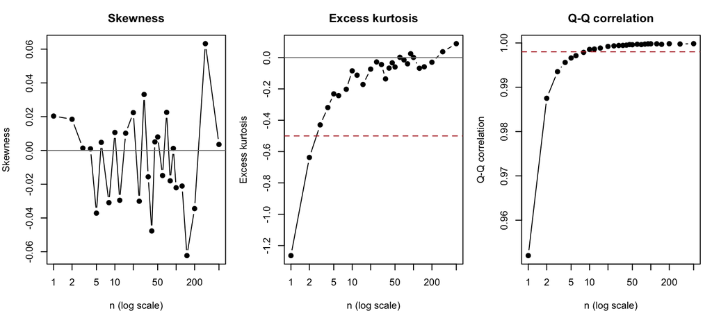

```r
plot_convergence(tab)
```

## 5 Theory vs. simulation

- **Mean:** every simulated mean is within 0.029 of 3.5.
- **Standard error:** simulated SE / $(\sigma/\sqrt n)$ ranged from 0.984 to 1.012. The formula works.
- **Shape:** skewness stays near 0 the whole time (largest |skewness| = 0.063), exactly as predicted. Kurtosis starts at -1.26 and climbs toward 0.

## 6 When is it approximately normal?

$$\boxed{n = 10}$$

At $n = 10$ the skewness is 0.011, the excess kurtosis is -0.085, and the Q-Q correlation is 0.9985. Kurtosis actually passed my cutoff earlier (around $n = 3$, like theory said). The thing that held it back was the **Q-Q correlation**, because with only a handful of possible values the Q-Q plot is a staircase instead of a line.

## 7 What surprised me?

At just $n = 2$ the histogram is already a triangle, and by $n = 5$ it honestly *looks* bell-shaped to the eye. But the Shapiro-Wilk test rejects normality at 21 of the 27 sample sizes, including $n = 30$ (p = 6.9e-05). That’s not because the shape is wrong. It’s because the mean of $n$ dice can only take a limited set of values, and a test with 5,000 values is sensitive enough to notice the data is *discrete*. That’s a good example of “statistically detectable” not being the same as “practically important.”

```r
save_results("Six-Sided Die", tab, n_star,
             "Symmetric, so only light tails + discreteness slow it down")
```